# Laboratorio 2

Grupo 5

2023-11-21

## Pregunta 1

Desarrollo pregunta 1:

### Pregunta 1.1

Descargar la página web https://www.mediawiki.org/wiki/MediaWiki y almacenarla en un formato de R apto para ser tratado. A continuacion se muestra el codigo de ejecucion:

```r
url_base <- "https://www.mediawiki.org/wiki/MediaWiki"

# version librerias httr y XML
html <- GET(url_base)
content <- content(html, as = "text")
parsedHtml <- htmlParse(content, asText = TRUE)

# version usando la libreria rvest:
content_rvest <- read_html(url_base)
```

### Pregunta 1.2

Analizar el contenido de la web, buscando el título de la página (que en HTML se etiqueta como “title”).

```
## [1] "MediaWiki"
```

### Pregunta 1.3

Analizar el contenido de la web, buscando todos los enlaces (que en HTML se etiquetan como “a”), buscando el texto del enlace, así como la URL.

| enlaces | texto |
| --- | --- |
| #bodyContent | Jump to content |
| /wiki/MediaWiki | Main page |
| /wiki/Download | Get MediaWiki |
| /wiki/Special:MyLanguage/Category:Extensions | Get extensions |
| //techblog.wikimedia.org/ | Tech blog |
| /wiki/Special:MyLanguage/How_to_contribute | Contribute |
| /wiki/Special:MyLanguage/Help:Contents | User help |
| /wiki/Special:MyLanguage/Manual:FAQ | FAQ |
| /wiki/Special:MyLanguage/Manual:Contents | Technical manual |
| /wiki/Project:Support_desk | Support desk |
| /wiki/Special:MyLanguage/Communication | Communication |
| https://developer.wikimedia.org/ | Developer portal |
| /wiki/Development_statistics | Code statistics |
| /wiki/Project:Help | Community portal |
| /wiki/Special:RecentChanges | Recent changes |
| /wiki/Special:LanguageStats | Translate content |
| /wiki/Special:Random | Random page |
| /wiki/Project:Village_Pump | Village pump |
| /wiki/Project:Sandbox | Sandbox |
| /wiki/MediaWiki |  |
| /wiki/Special:Search | Search |
| # | English |
| /w/index.php?title=Special:CreateAccount&returnto=MediaWiki | Create account |
| /w/index.php?title=Special:UserLogin&returnto=MediaWiki | Log in |
| /w/index.php?title=Special:CreateAccount&returnto=MediaWiki | Create account |
| /w/index.php?title=Special:UserLogin&returnto=MediaWiki | Log in |
| /wiki/Help:Introduction | learn more |
| /wiki/Special:MyContributions | Contributions |
| /wiki/Special:MyTalk | Talk |
| /wiki/MediaWiki | Main Page |

[output cut: 140 more lines]

### Pregunta 1.4

Generar una tabla con cada enlace encontrado, indicando el texto que acompaña el enlace, y el número de veces que aparece un enlace con ese mismo objetivo.

| Registros | Suma_Repeticiones |
| --- | --- |
|  | 3 |
|  | 7 |
| Create account | 1 |
| Log in | 1 |
|  | 1 |
| English | 1 |
| Search | 1 |
| About mediawiki.org | 1 |
| Afrikaans | 1 |
| asturianu | 1 |
| Bahasa Indonesia | 1 |
| Bahasa Melayu | 1 |
| bosanski | 1 |
| català | 1 |
| čeština | 1 |
| Cite this page | 1 |
| Code of Conduct | 1 |
| Code statistics | 1 |
| Communication | 1 |
| Community portal | 1 |
| configure | 1 |
| Contribute | 1 |
| Contributions | 1 |
| Cookie statement | 1 |
| Create a book | 1 |
| Create account | 1 |
| Creative Commons Attribution-ShareAlike License | 1 |
| dansk | 1 |
| Deutsch | 1 |
| developer documentation | 1 |

[output cut: 128 more lines]

### Pregunta 1.5

Para cada enlace, seguirlo e indicar si está activo (podemos usar el código de status HTTP al hacer una petición a esa URL)

| Enlace | Estado |
| --- | --- |
| #bodyContent | 200 |
| /wiki/MediaWiki | 404 |
| /wiki/Download | 404 |
| /wiki/Special:MyLanguage/Category:Extensions | 404 |
| //techblog.wikimedia.org/ | 404 |
| /wiki/Special:MyLanguage/How_to_contribute | 404 |
| /wiki/Special:MyLanguage/Help:Contents | 404 |
| /wiki/Special:MyLanguage/Manual:FAQ | 404 |
| /wiki/Special:MyLanguage/Manual:Contents | 404 |
| /wiki/Project:Support_desk | 404 |
| /wiki/Special:MyLanguage/Communication | 404 |
| https://developer.wikimedia.org/ | 200 |
| /wiki/Development_statistics | 404 |
| /wiki/Project:Help | 404 |
| /wiki/Special:RecentChanges | 404 |
| /wiki/Special:LanguageStats | 404 |
| /wiki/Special:Random | 404 |
| /wiki/Project:Village_Pump | 404 |
| /wiki/Project:Sandbox | 404 |
| /wiki/MediaWiki | 404 |
| /wiki/Special:Search | 404 |
| # | 200 |
| /w/index.php?title=Special:CreateAccount&returnto=MediaWiki | 404 |
| /w/index.php?title=Special:UserLogin&returnto=MediaWiki | 404 |
| /w/index.php?title=Special:CreateAccount&returnto=MediaWiki | 404 |
| /w/index.php?title=Special:UserLogin&returnto=MediaWiki | 404 |
| /wiki/Help:Introduction | 404 |
| /wiki/Special:MyContributions | 404 |
| /wiki/Special:MyTalk | 404 |
| /wiki/MediaWiki | 404 |

[output cut: 140 more lines]

## Pregunta 2

Desarrollo pregunta 2:

### 2.1 Histograma —————————————————————————————–

Histograma con la frecuencia de aparición de los enlaces, separado por URLs absolutas y URLs relativas

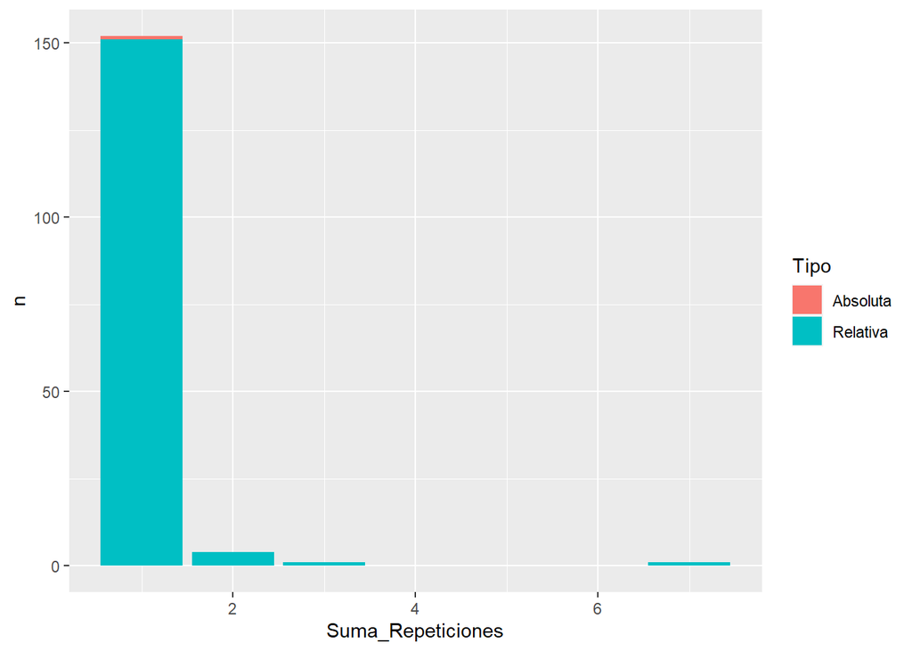

### 2.2 Gráfico de barras —————————————————————————————–

Gráfico de barras con la cantidad de enlaces que apuntan a otros dominios o servicios (distinto a https://www.mediawiki.org

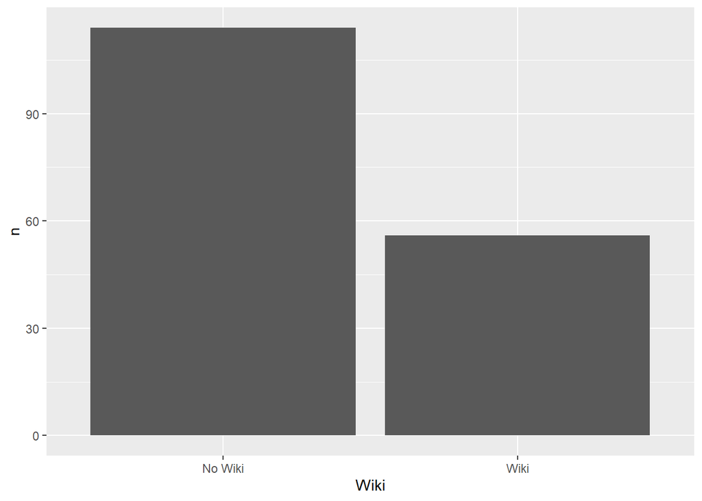

### 2.3 Gráfico de tarta —————————————————————————————–

Gráfico de tarta indicando los porcentajes de Status de activos y no activos

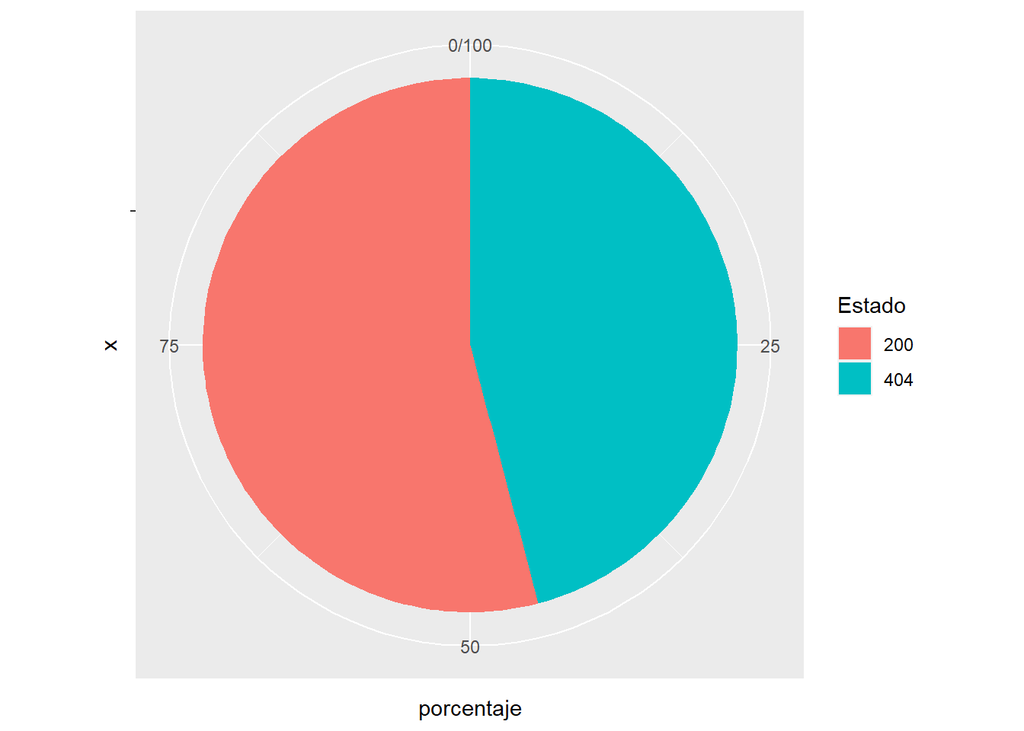